# ISAR example

Tuomas Rajala

2016-03-16

This vignette demonstrates the ISAR summary computation.

# Data

Let’s look at the multitype pattern `lansing`

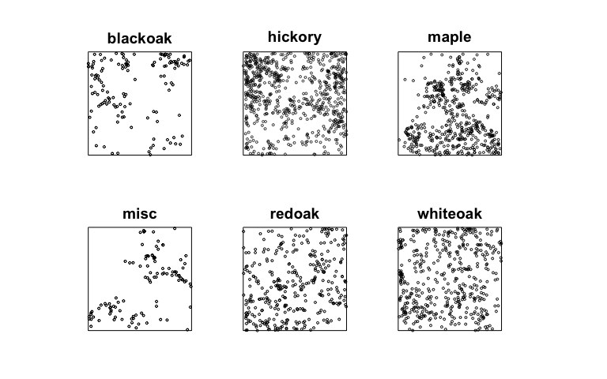

```r
library(spatstat)
library(sseg)
xl <- split(lansing)
par(mar=c(0,0,0,0))
plot(xl, cex=.4, main="")
```

# Intensity

To compute the inhomogeneous ISAR we need to estimate the intensity per point per type. We can estimate the intensities using kernel smoothing. The bandwidth needs to be chosen, and one criteria is to minimize $L(h)=(\sum_{x\in X_i}\frac{1}{\lambda_i(x; h)}-|W|)^2$ To do this for each pattern there is a wrapper:

```r
A <- intensity_optimal(lansing, verb = T)
```

```
## 6 types: 1 2 3 4 5 6
```

```r
print(summary(A))
```

```
##       type   best_bw on_edge
## 1 blackoak 0.5257450   FALSE
## 2  hickory 0.3272197   FALSE
## 3    maple 2.6569843   FALSE
## 4     misc 0.7502862   FALSE
## 5   redoak 0.6932731   FALSE
## 6 whiteoak 0.2118678   FALSE
```

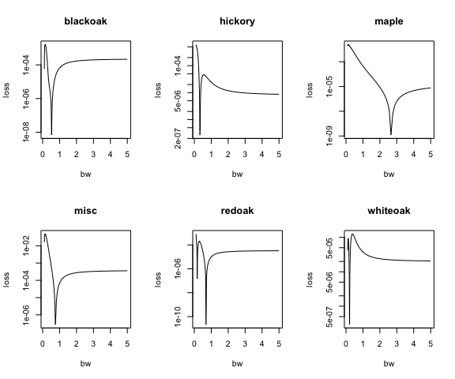

```r
par(mfrow=c(2,3))
plot(A, i=1:6, type="l", log="y")
```

And to see the intensity estimates

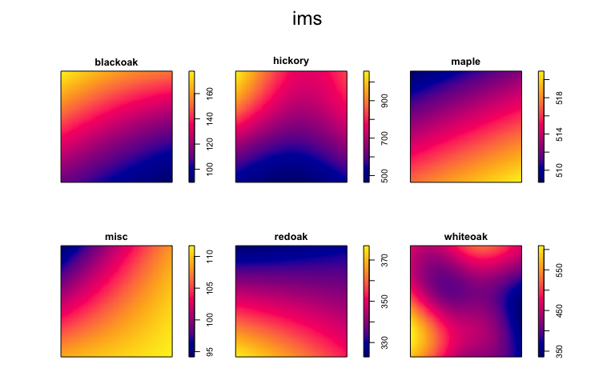

```r
ims <- density_ppplist(xl, sigma = A$bandwidth)
plot(ims, equal.ribbon = F)
```

# ISAR

Now let’s compute the ISAR values. We need to specify a target type. A function `ISAR` computes both homogeneous and inhomogeneous, depending whether we specify the parameter `intensity`. Here’s and example of homogeneous ISAR:

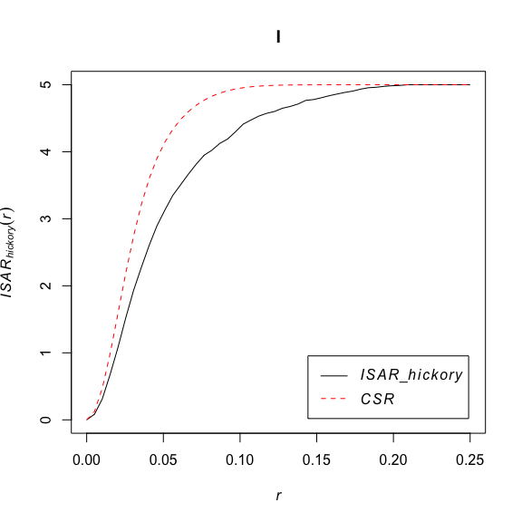

```r
I <- ISAR(lansing, "hickory", CSR=TRUE)
plot(I)
```

Since the pattern of hickories seem clustered,

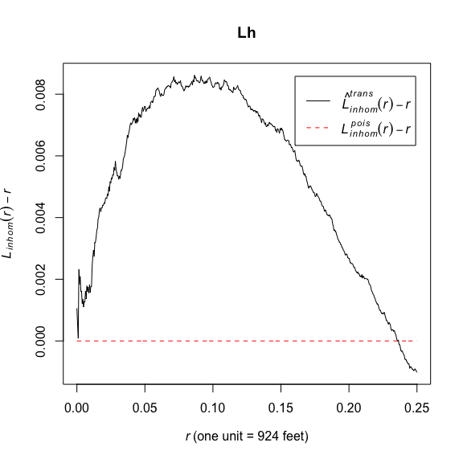

```r
Lh <- Linhom(xl[["hickory"]], ims[["hickory"]], correction = "trans")
plot(Lh, .-r~r)
```

there are a lot of same types around for ISAR, so we get less alien types than would be expected if everything was random. Note that CSR is much stronger independence than independence between types, and rarely a good null model for multitypes.

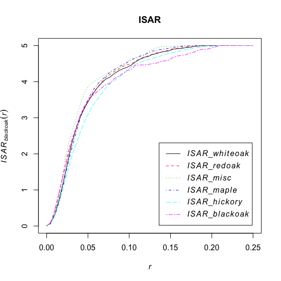

```r
Il <- lapply(names(xl), ISAR, x=lansing)
ISAR <- do.call(cbind, Il)
plot(ISAR)
```

And then the inhomogeneous ones:

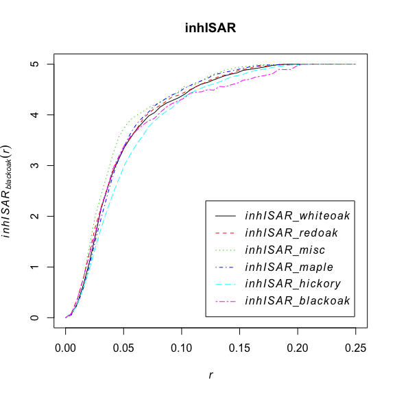

```r
Iil <- lapply(names(xl), ISAR, x=lansing, intensity = A$intensity)
# or
# Iil <- lapply(names(xl), ISAR, x=lansing, intensity = ims)

inhISAR <- do.call(cbind, Iil)
plot(inhISAR)
```

The differences (a bit ugly):

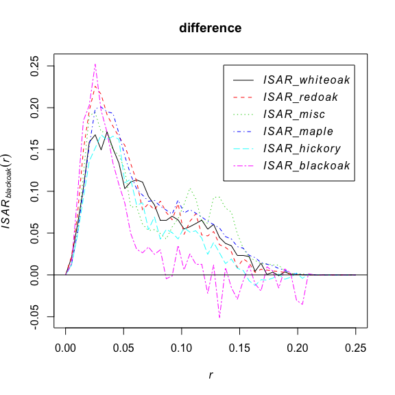

```r
Idl <- lapply(seq_along(xl), function(s) {
    k <- Il[[s]]
    k[,2] <- Il[[s]]$ISAR - Iil[[s]]$inhISAR
    k
  })
difference <- do.call(cbind, Idl)
plot(difference)
abline(h=0)
```

We see that most of the homogeneous values are higher that inhomogeneous values.